# 05 Evaluating Classification Supervised Learning Model Quality

In machine learning, particularly for classification tasks, understanding the robustness and predictive quality of your model is crucial. Accuracy alone doesn’t paint the complete picture. There are numerous metrics and visualizations which, when combined, provide a comprehensive assessment of model performance. This guide elucidates these metrics and what they’re specifically used for.

Data source: Kaggle’s mushroom classification data set from https://www.kaggle.com/datasets/uciml/mushroom-classification

# Prepare the workspace

```r
options(
  digits = 2,
  scipen = 999,
  warn = -1
)
rm(
  list = ls()
)
library(magrittr)
```

# 1. Load our data, fit a logistic regression model

Here we split our data into 2 sets, training and test. Normally if we have a lot of data we should include a validation set. However when data is not plenty, we want to use as much information as we have currently and so a training and test set will suffice. OR if we know which model we want to use, we can skill the validation set since the purpose of the validation set is to see which model/algorythm performs the best.

```r
M <- readr::read_csv(
  file = "/Users/thienpham/Data Mining/data/prepared_mushrooms.csv",
  col_types = "cnnnnnnnnnnnnnnnnnnnnnn"
) %>%
  dplyr::mutate(
    train_test = ifelse(runif(dplyr::n()) > 0.5,"Train","Test")
  ) %>%
  as.data.frame()


# First we train the data
glm_mushrooms <- glm(
  formula = target ~ population * gill_color * bruises, # using * instead of + allows for all levels of interaction
  family = "binomial",
  data = M %>%
    dplyr::filter(train_test == "Train") # training on our train data
)


# After getting a model now we want predictions
M <- M %>%
  dplyr::mutate(
    predict_probability = predict(
      object = glm_mushrooms,
      newdata = M,
      type = "response" # response gives us the probability, link function gives us log odds, terms is the third option
    ),
    predict_class = round(predict_probability) # this gives us the classification
  ) # this says if the probability > .5 we say its edible, < .5 = poisonous
# We can change the threshold if we want to, would you trust a 50% probability for something that could be edible or poisonous? of course not, we would probably want .90 or something higher. All in the context.
```

# 2. Classification Metrics

```r
split_M <- M %>%
  dplyr::select(target,predict_class,train_test) %>%
  dplyr::group_by(train_test) %>%
  split(f = M$train_test)


for(j in names(split_M)){
  print("-------------------------------------------------------------------")
  print(j)
  print(
    x = caret::confusionMatrix(
      data = factor(split_M[[j]]$predict_class),
      reference = factor(split_M[[j]]$target),
      mode = "everything"
    )
  )
}
```

```
## [1] "-------------------------------------------------------------------"
## [1] "Test"
## Confusion Matrix and Statistics
##
##           Reference
## Prediction    0    1
##          0 1541  327
##          1  410 1785
##
##                Accuracy : 0.819
##                  95% CI : (0.806, 0.83)
##     No Information Rate : 0.52
##     P-Value [Acc > NIR] : < 0.0000000000000002
##
##                   Kappa : 0.636
##
##  Mcnemar's Test P-Value : 0.00252
##
##             Sensitivity : 0.790
##             Specificity : 0.845
##          Pos Pred Value : 0.825
##          Neg Pred Value : 0.813
##               Precision : 0.825
##                  Recall : 0.790
##                      F1 : 0.807
##              Prevalence : 0.480
##          Detection Rate : 0.379
##    Detection Prevalence : 0.460
##       Balanced Accuracy : 0.818
##
##        'Positive' Class : 0
##
## [1] "-------------------------------------------------------------------"
## [1] "Train"
## Confusion Matrix and Statistics
##
##           Reference
## Prediction    0    1
##          0 1579  321
##          1  386 1775
```

[output cut: 9 more lines]

```
##
##             Sensitivity : 0.804
##             Specificity : 0.847
##          Pos Pred Value : 0.831
##          Neg Pred Value : 0.821
##               Precision : 0.831
##                  Recall : 0.804
##                      F1 : 0.817
##              Prevalence : 0.484
##          Detection Rate : 0.389
##    Detection Prevalence : 0.468
##       Balanced Accuracy : 0.825
##
##        'Positive' Class : 0
##
```

We have .83% accuracy, confidence interval, … If we have unbalanced data set (1% of data is fradulent) then using balanced accuracy is better than the accuracy at the top.

Remember training statistics should be best, then validation, then test. If validation is noticebaly larger than training, or test larger than validation, something is up like outliers or anomalies floating around that we need to fix. Normally the lower value would be the one with the outlier. ### Accuracy

**Definition:**
$$\text{Accuracy} = \frac{TP + TN}{TP + TN + FP + FN}$$

It measures the proportion of correct predictions in the total predictions made. It’s most useful when classes are balanced. Beware of relying solely on accuracy in imbalanced datasets.

### Sensitivity (Recall)

**Definition:**
$$\text{Sensitivity} = \frac{TP}{TP + FN}$$

Measures the proportion of actual positives that were correctly identified. It’s particularly valuable in situations where False Negatives are costly, like detecting a disease.

### Specificity

**Definition:**
$$\text{Specificity} = \frac{TN}{TN + FP}$$

Demonstrates the ability of the model to correctly identify negative instances. High specificity means few false alarms.

### Precision

**Definition:**
$$\text{Precision} = \frac{TP}{TP + FP}$$

Precision evaluates the correctness of positive predictions. It’s crucial in scenarios where the cost of a false positive is high, like in spam detection.

### Confusion Matrix

A matrix representation of true vs. predicted classifications. It gives a holistic view of how well the model is performing across different classes.

### F1-Score

**Definition:**
$$\text{F1-Score} = 2 \times \frac{Precision \times Sensitivity}{Precision
+ Sensitivity}$$

A balance between precision and sensitivity. It’s beneficial when the class distribution is uneven and you want a measure that considers both false positives and false negatives.

### Area under the Curve (AUC)

AUC evaluates the model’s performance across various threshold values. A model with an AUC closer to 1 is ideal for binary classification problems, signifying that it has a good measure of separability.

```r
prediction_Train <- ROCR::prediction(
  predictions = M$predict_probability[M$train_test == "Train"],
  labels = M$target[M$train_test == "Train"]
)
ROCR::performance(
  prediction.obj = prediction_Train,
  measure = "auc"
)@y.values
```

```
## [[1]]
## [1] 0.9
```

```r
prediction_Test <- ROCR::prediction(
  predictions = M$predict_probability[M$train_test == "Test"],
  labels = M$target[M$train_test == "Test"]
)
ROCR::performance(
  prediction.obj = prediction_Test,
  measure = "auc"
)@y.values
```

```
## [[1]]
## [1] 0.89
```

```r
# Above we used auc = area under curve but ROCR has other measures that we could use listed below:
c(
  "acc","auc","aucpr","cal","chisq","cost","ecost","err","f","fall","fnr","fpr",
  "lift","mat","mi","miss","mxe","npv","odds","pcfall","pcmiss","phi","ppv",
  "prbe","prec","rch","rec","rmse","rnp","rpp","sar","sens","spec","tnr","tpr"
)
```

```
##  [1] "acc"    "auc"    "aucpr"  "cal"    "chisq"  "cost"   "ecost"  "err"
##  [9] "f"      "fall"   "fnr"    "fpr"    "lift"   "mat"    "mi"     "miss"
## [17] "mxe"    "npv"    "odds"   "pcfall" "pcmiss" "phi"    "ppv"    "prbe"
## [25] "prec"   "rch"    "rec"    "rmse"   "rnp"    "rpp"    "sar"    "sens"
## [33] "spec"   "tnr"    "tpr"
```

As the curve gets close to the top it hits diminishing returns. To get the optimal criteria for edible cut off, we can consider what point along the curve is closest to the top left corner. So .7 on y axis was high enough to declare edible.

For model quality, a perfect model would show the area under the curve being 1 or a full square. ex: a traingle would show 50% discrimination or random guessing so that would be a bad model.

### Akaike’s Information Criterion (AIC) and Bayesian Information Criterion (BIC)

Both AIC and BIC help in model selection by considering the goodness of fit and the model complexity. Lower values indicate a better model.

```r
AIC(
  object = glm_mushrooms
)
```

```
## [1] 3016
```

```r
BIC(
  object = glm_mushrooms
)
```

```
## [1] 3067
```

## Classification Visualizations

### Bar Plot: Correct Value by Predicted

Understand the distribution of predicted classes against the actual classes. When the model predicted 0 or 1, what is the percentage of obs the model got correct.

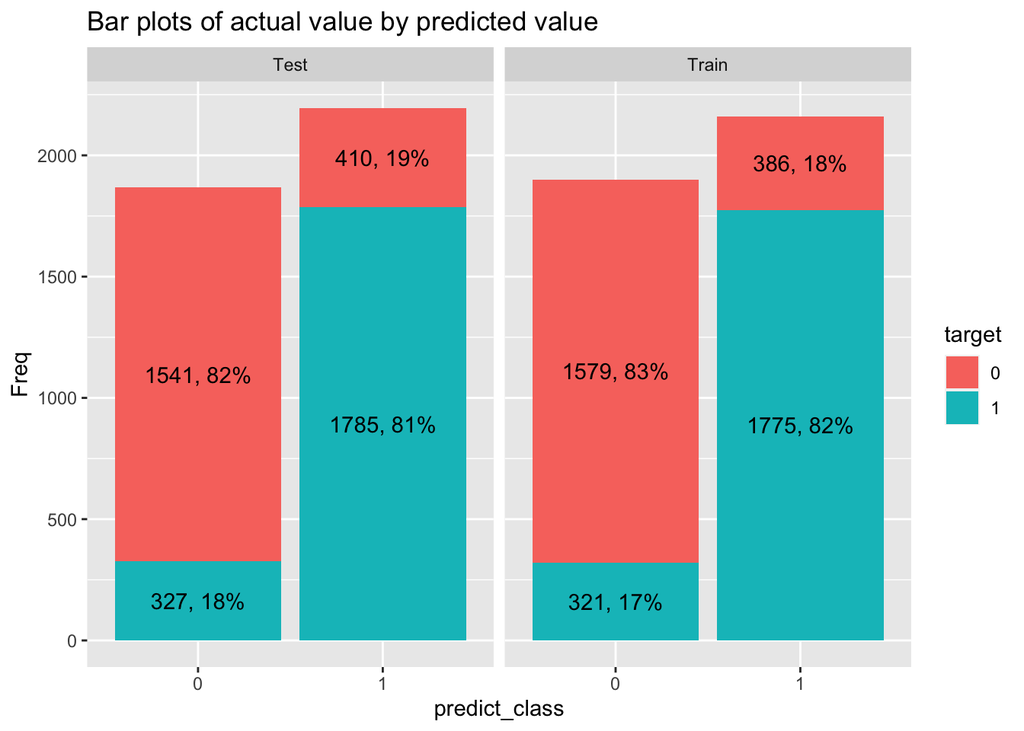

```r
library(ggplot2)
M %>%
  dplyr::select(target,predict_class,train_test) %>%
  table() %>%
  as.data.frame() %>%
  dplyr::group_by(train_test,predict_class) %>%
  dplyr::mutate(percent = round(100*Freq/sum(Freq)),label = paste0(Freq,", ",percent,"%")) %>%
  dplyr::ungroup() %>%
  ggplot() +
  aes(x = predict_class,y = Freq,fill = target,label = label) +
    geom_col() +
  geom_text(position = position_stack(0.5)) +
    facet_grid(~train_test) +
  labs(
    title = "Bar plots of actual value by predicted value"
  )
```

### Bar Plot: Predicted Value by Correct Value

Visualizes the distribution of predictions for each actual class, offering insights into model’s biases. When the true value was 0 or 1, what percentage did the model predict correct.

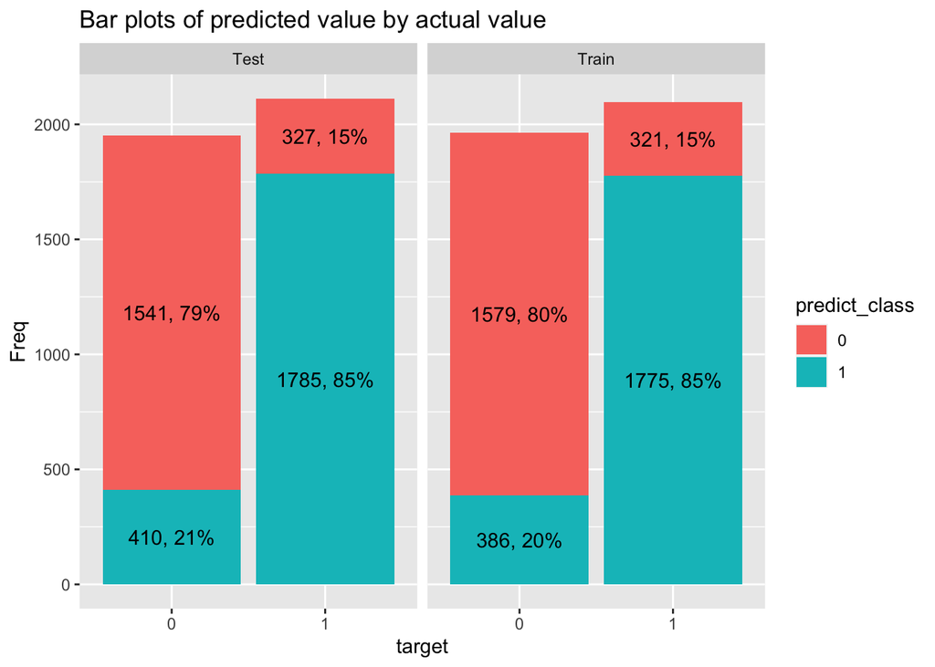

```r
M %>%
  dplyr::select(target,predict_class,train_test) %>%
  table() %>%
  as.data.frame() %>%
  dplyr::group_by(train_test,target) %>%
  dplyr::mutate(percent = round(100*Freq/sum(Freq)),label = paste0(Freq,", ",percent,"%")) %>%
  dplyr::ungroup() %>%
  ggplot() +
  aes(x = target,y = Freq,fill = predict_class,label = label) +
    geom_col() +
  geom_text(position = position_stack(0.5)) +
    facet_grid(~train_test) +
  labs(
    title = "Bar plots of predicted value by actual value"
  )
```

### ROC Curve

Plots true positive rate against false positive rate at various thresholds. It gives insights into the trade-offs between sensitivity and specificity.

First plot it for training, second is for test.

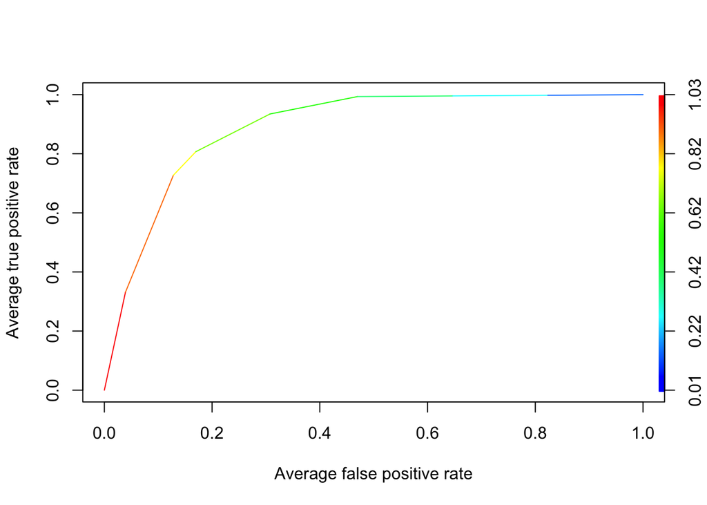

```r
plot(
  x = ROCR::performance(
    prediction.obj = prediction_Train,
    measure = "tpr", x.measure = "fpr"
  ),
  avg = "threshold",
  colorize = TRUE
)
```

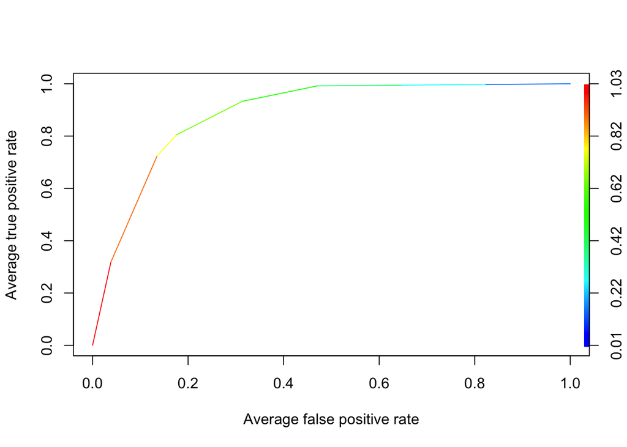

```r
plot(
  x = ROCR::performance(
    prediction.obj = prediction_Test,
    measure = "tpr", x.measure = "fpr"
  ),
  avg = "threshold",
  colorize = TRUE
)
```

### Bubble Plot of Confusion Matrix

A visual representation of the confusion matrix, where bubble size indicates the number of instances, making misclassifications more apparent.

If there is a big difference between train and test statistics, again that is a sign of overfitting.

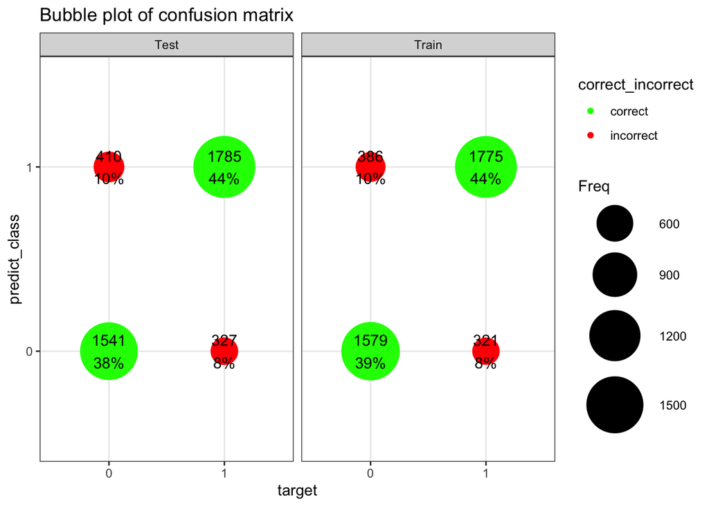

```r
M %>%
  dplyr::select(target,predict_class,train_test) %>%
  table() %>%
  as.data.frame() %>%
  dplyr::group_by(train_test) %>%
  dplyr::mutate(percent = round(100*Freq/sum(Freq)),label = paste0(Freq,"\n",percent,"%"),correct_incorrect = ifelse(predict_class == target,"correct","incorrect")) %>%
  dplyr::ungroup() %>%
  ggplot() +
  aes(x = target,y = predict_class,label = label,) +
    geom_point(mapping = aes(size = Freq,color = correct_incorrect)) +
  geom_text() +
  facet_grid(~train_test) +
  scale_size_area(max_size = 20) +
  labs(
    title = "Bubble plot of confusion matrix"
  ) +
  theme_bw() +
  scale_color_manual(values = c("green","red1"))
```

### Box Plots of Modeled Probability by Target Variable

Displays the distribution of model-predicted probabilities by the actual class, helping to understand the model’s certainty in its predictions.

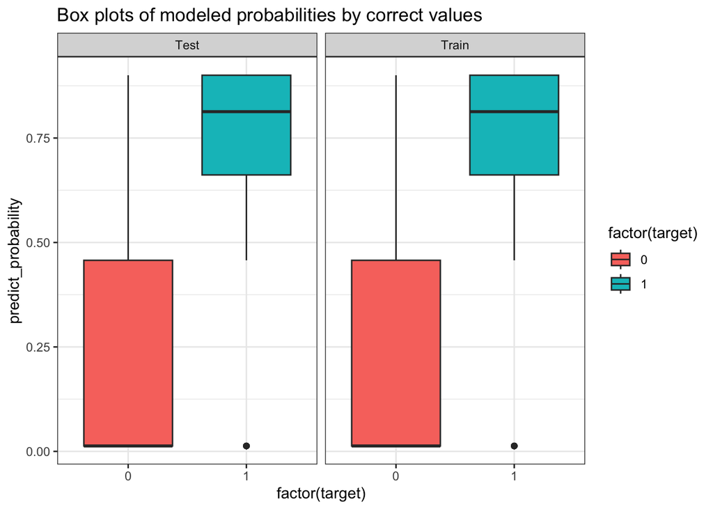

```r
M %>%
  dplyr::select(target,predict_class,predict_probability,train_test) %>%
  dplyr::mutate(correct_incorrect = ifelse(predict_class == target,"correct","incorrect")) %>%
  dplyr::ungroup() %>%
ggplot() +
  aes(x = factor(target),y = predict_probability,fill = factor(target)) +
  geom_boxplot() +
  facet_grid(~train_test) +
  labs(
    title = "Box plots of modeled probabilities by correct values"
  ) +
  theme_bw()
```

## Conclusion

Evaluation metrics and visualizations form the bedrock of understanding a classification model’s performance. They provide insights that go beyond a single metric, capturing nuances, and ensuring that the model isn’t just accurate but also reliable across various scenarios. Proper model evaluation is the key to deriving meaningful, actionable insights from your data.

## Homework Assignment

1. **Model Building**: Construct a logistic regression model using a dataset of your choice.
2. **Metrics Application**:
   - Compute accuracy, sensitivity, specificity, precision, and F1-score.
   - Determine the AIC and BIC values for your model.
3. **Visualizations**:
   - Create visual representations for your model’s performance, like bar plots and the ROC curve.